# Lab01

Elijah Boulton

January 20, 2019

# Task 1

The working directory

```r
getwd()
```

```
## [1] "D:/Eli/Classes/MATH4753/Lab Files/Lab01"
```

# Task 2

First 6 lines of data

```r
ddt = read.csv("DDT.csv")
head(ddt)
```

```
##   RIVER MILE  SPECIES LENGTH WEIGHT DDT
## 1   FCM    5 CCATFISH   42.5    732  10
## 2   FCM    5 CCATFISH   44.0    795  16
## 3   FCM    5 CCATFISH   41.5    547  23
## 4   FCM    5 CCATFISH   39.0    465  21
## 5   FCM    5 CCATFISH   50.5   1252  50
## 6   FCM    5 CCATFISH   52.0   1255 150
```

# Task 3

Qualitative variables are listed as true, quantitative are listed as false:

```r
unlist(lapply(ddt, is.factor))
```

```
##   RIVER    MILE SPECIES  LENGTH  WEIGHT     DDT
##    TRUE   FALSE    TRUE   FALSE   FALSE   FALSE
```

Species in the data set:

```r
levels(ddt$SPECIES)
```

```
## [1] "CCATFISH"  "LMBASS"    "SMBUFFALO"
```

Data for LMBASS with a weight greater than 800 grams

```r
temp = with(ddt, ddt[WEIGHT>800 & SPECIES == "LMBASS",])
print(temp)
```

```
##     RIVER MILE SPECIES LENGTH WEIGHT DDT
## 141   TRM  345  LMBASS     30    856 2.2
## 144   TRM  345  LMBASS     36   1433 1.9
```

Data for fish from the SCM river with DDT greater than 4.0

```r
temp = with(ddt, ddt[RIVER == "SCM" & DDT > 4.0,])
print(temp)
```

```
##    RIVER MILE  SPECIES LENGTH WEIGHT DDT
## 16   SCM    1 CCATFISH     45    984 9.1
## 17   SCM    1 CCATFISH     43    965 7.8
## 18   SCM    1 CCATFISH     45   1084 4.1
```

Clicker Questions:

Q.1 The mean length of fish in ddt is 42.81

Q.2 The standard deviation of fish weight in ddt is 376.5461

Q.3 The answer is 0

Q.4 The last value of v/20 is 1.00

# Task 4

Table of the rivers

```r
tabRVR = table(ddt$RIVER)
print(tabRVR)
```

```
##
## FCM LCM SCM TRM
##   6   6   6 126
```

Colored barplot of the rivers

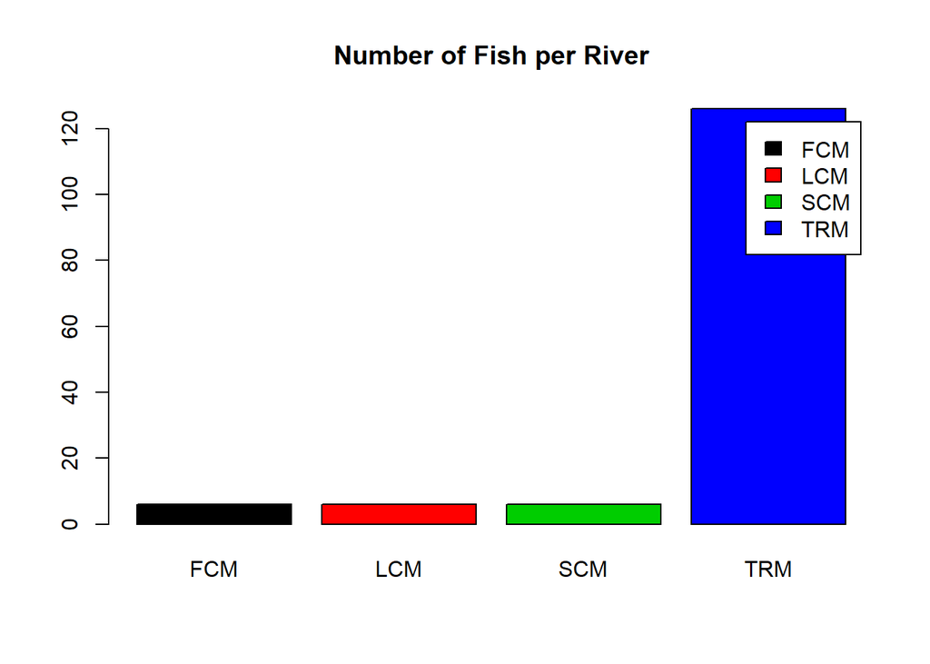

```r
library(ggplot2)
barRVR = barplot(tabRVR, beside = TRUE, col = 1:4, legend.text = TRUE, main = "Number of Fish per River")
```

Table of rivers crossed with species of fish

```r
tabRF = with(ddt, table(SPECIES, RIVER))
print(tabRF)
```

```
##            RIVER
## SPECIES     FCM LCM SCM TRM
##   CCATFISH    6   6   6  78
##   LMBASS      0   0   0  12
##   SMBUFFALO   0   0   0  36
```

Barplot of river crossed with species of fish

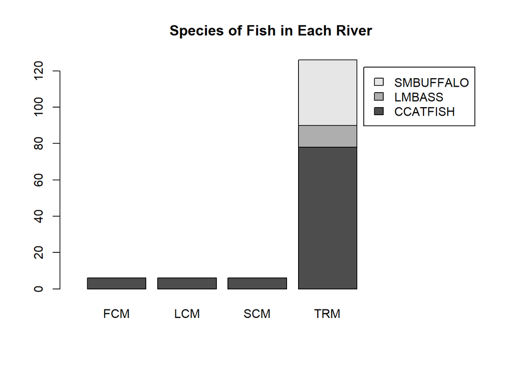

```r
barRF = barplot(tabRF, main = "Species of Fish in Each River", legend.text = TRUE, width = 3, xlim = c(0, 20))
```

# Task 5

Pie chart of fish species

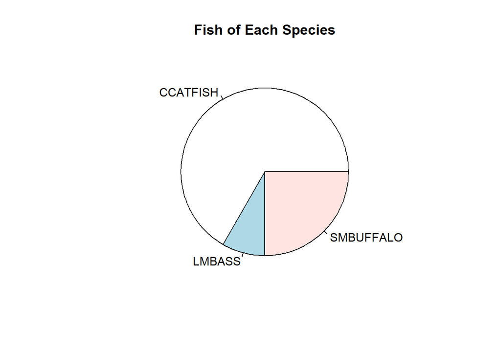

```r
tabS = with(ddt, table(SPECIES))
pie(tabS, main = "Fish of Each Species")
```

Pie chart of rivers

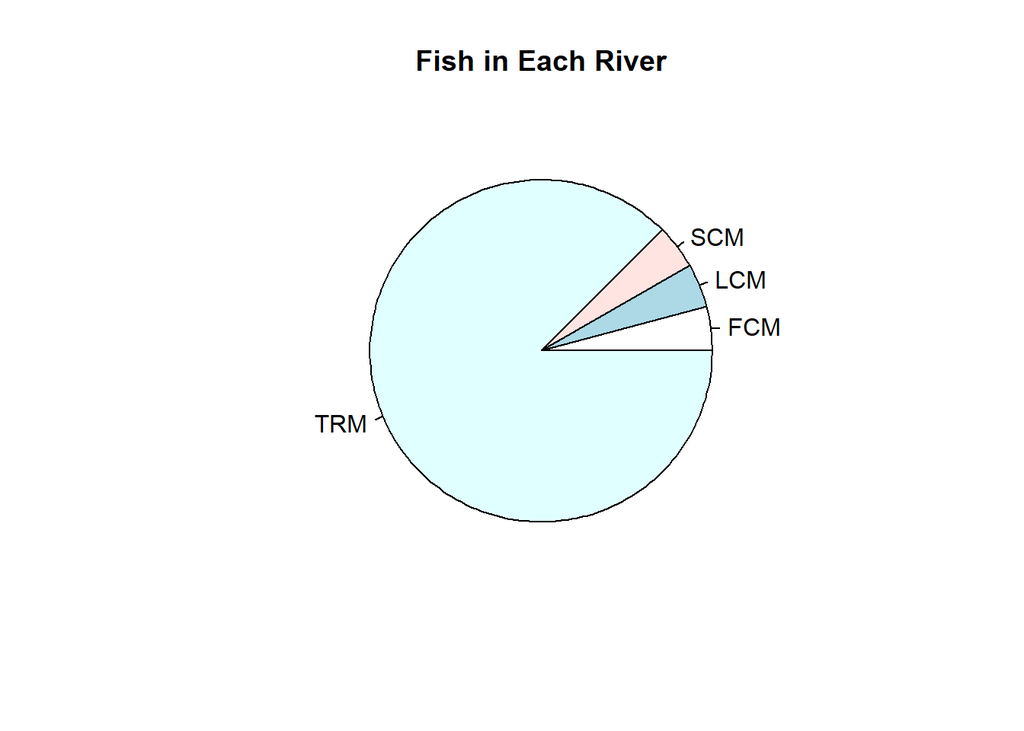

```r
tabR = with(ddt, table(RIVER))
pie(tabR, main = "Fish in Each River")
```

# Task 6

Boxplot of DDT levels

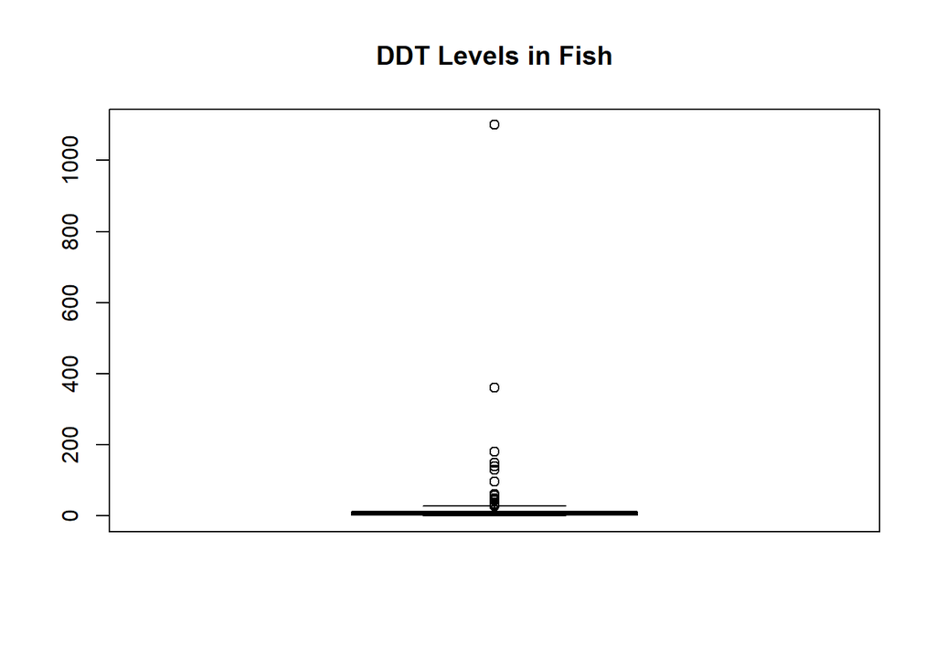

```r
BoxDDT = boxplot(ddt$DDT, main = "DDT Levels in Fish")
```

Boxplot of fish weight

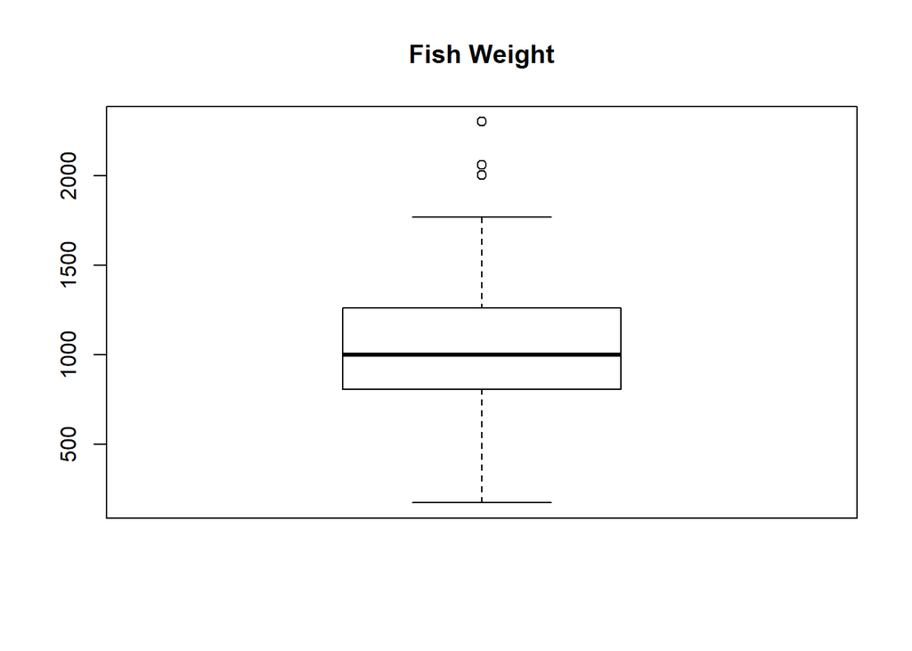

```r
BoxW = boxplot(ddt$WEIGHT, main = "Fish Weight")
```

Boxplot of fish length

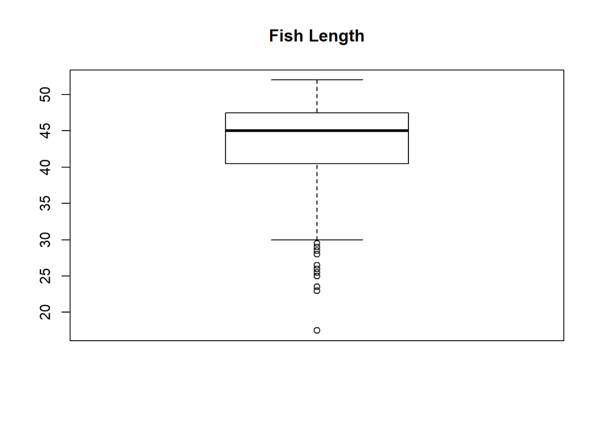

```r
BoxL = boxplot(ddt$LENGTH, main = "Fish Length")
```

# Task 7

Coplot of length vs weight for each river

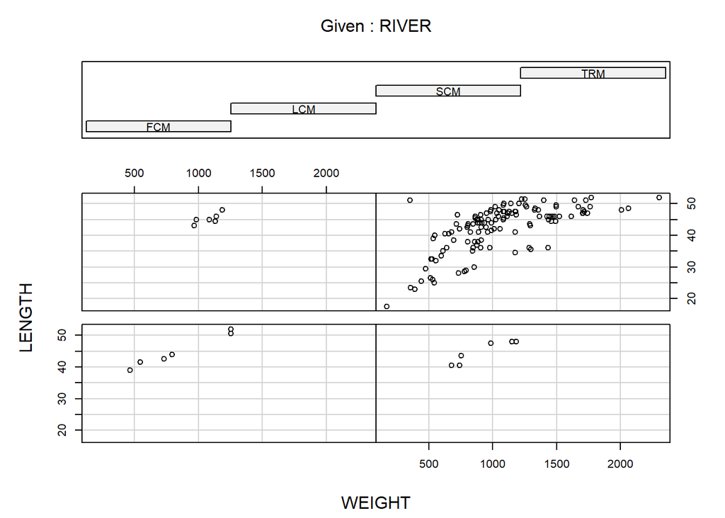

```r
LWRcoplot = coplot(LENGTH~WEIGHT|RIVER, data = ddt)
```

Coplot of DDT vs weight for each species

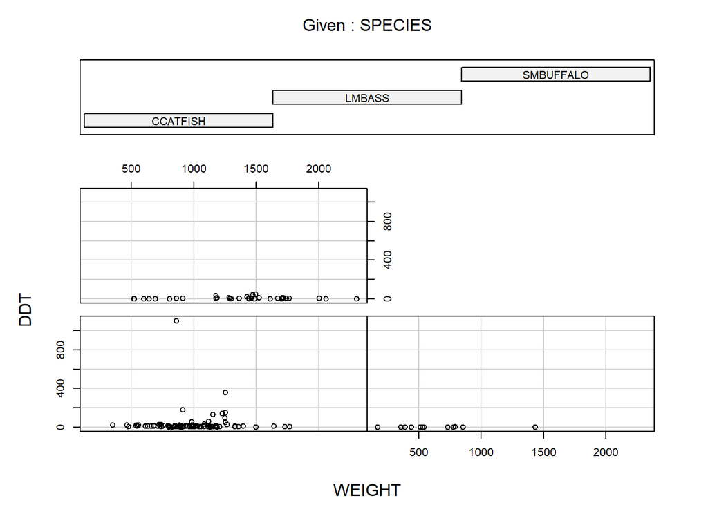

```r
LWRcoplot = coplot(DDT~WEIGHT|SPECIES, data = ddt)
```

# Task 8

Boxplot using ggplot

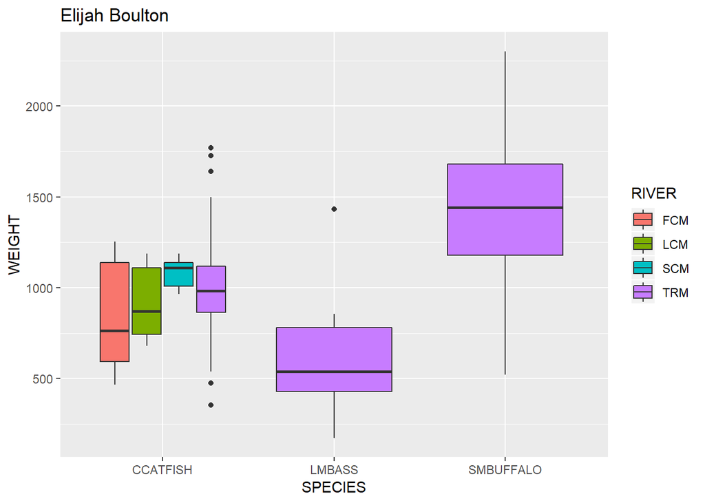

```r
gBox = ggplot(ddt, aes(x = SPECIES, y = WEIGHT)) +
  geom_boxplot(aes(fill = RIVER)) + ggtitle("Elijah Boulton")

print(gBox)
```

Violin plot using ggplot

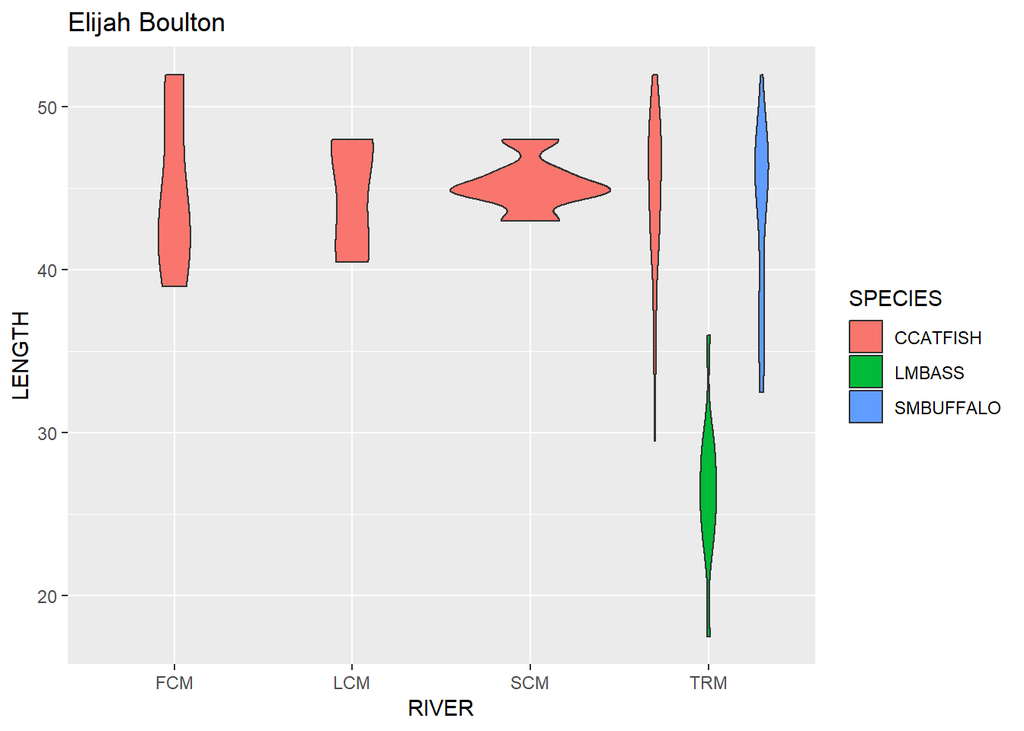

```r
gViolin = ggplot(ddt, aes(x = RIVER, y = LENGTH)) +
  geom_violin(aes(fill = SPECIES)) + ggtitle("Elijah Boulton")

print(gViolin)
```

Scatter plot using ggplot

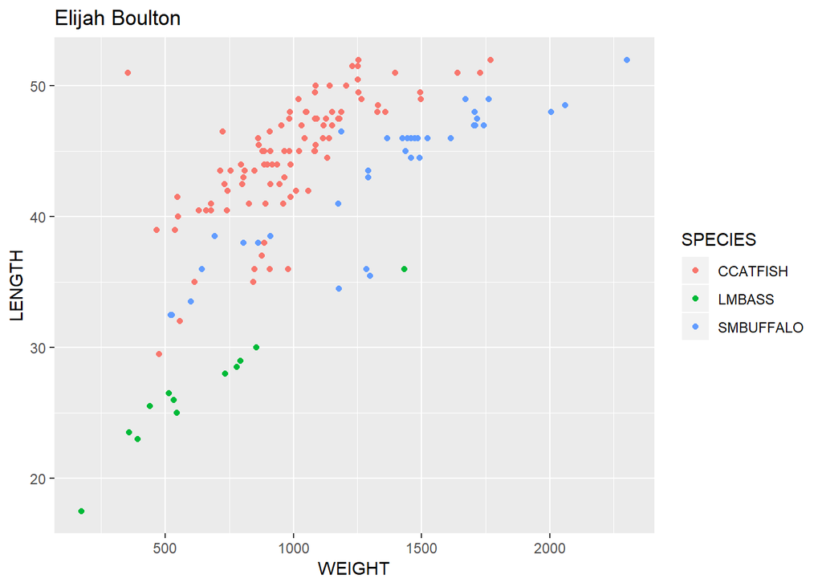

```r
gScatter = ggplot(ddt, aes(x = WEIGHT, y = LENGTH )) +
  geom_point(aes( col = SPECIES)) + ggtitle("Elijah Boulton")

print(gScatter)
```